# Fundamentals of Computing and Data Display

## Mapping

We pull a map of Washington state and the coordinates for the country boundaries from the maps package.

Next we need to clean the voting data and combine it with the county data so we can map it.

```r
votes <-
  votes %>%
  select(County, Race, Candidate, Votes, PercentageOfTotalVotes) %>%
  filter(Race %in% c(target, target2)) %>%
  mutate(subregion= tolower(County))

vote_loc <- right_join(wash_counties, votes, by = "subregion")
```

Then I filter the data so that we can visualize the percentage of voters who voted Yes on 1631 and map the results by county. This displays where people voted for Initiative 1631.

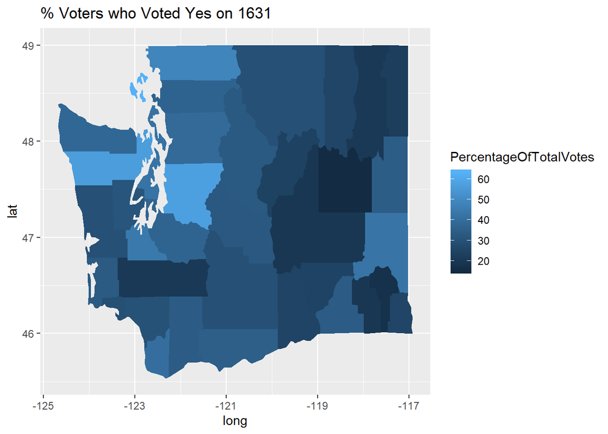

```r
results
```

We can also see where the many “No” Voters are located; there are many No voters.

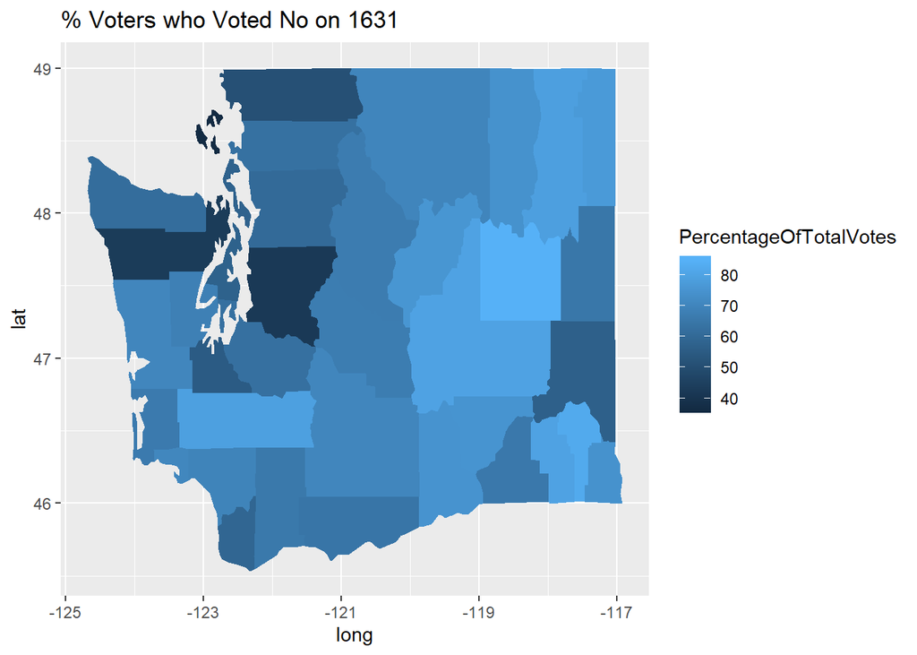

```r
no_results
```

## Discussion

Based on these findings, it appears that Initiative 1631 enjoyed far greater support among Twitter users than the voting population. However, the Twitter population is not a representative sample of the voting population. Further, many of the supporters on Twitter represented activist groups who used it to advertise or drum up support for the carbon tax. Twitter also over-represented urban and out-of-state residents, and voters in rural and even suburban areas are not well-represented on Twitter.